# Automatic transmission increases fuel consuption!

Sunday, November 23, 2014

Such result was obtained while answering these questions:

1. Is an automatic or manual transmission better for miles per gallon?
2. How much is quantitative difference if any?

### Synopsis

The analysis is based on the `mtcars` data which was extracted from the 1974 *Motor Trend* US magazine.

### Exploratory analysis

Exploring `mtcars` dataset we can notice, that some variables can be considered as factors. So, first of all, perform such kind of factorization:

```r
library(datasets)

mtcars$cyl  <- factor(mtcars$cyl)
mtcars$vs   <- factor(mtcars$vs)
mtcars$am   <- factor(mtcars$am, labels = c("Automatic", "Manual"))
mtcars$gear <- factor(mtcars$gear)
mtcars$carb <- factor(mtcars$carb)
```

Now, let’s find out how fuel consumption (further - mpg) differs for different types of transmission.

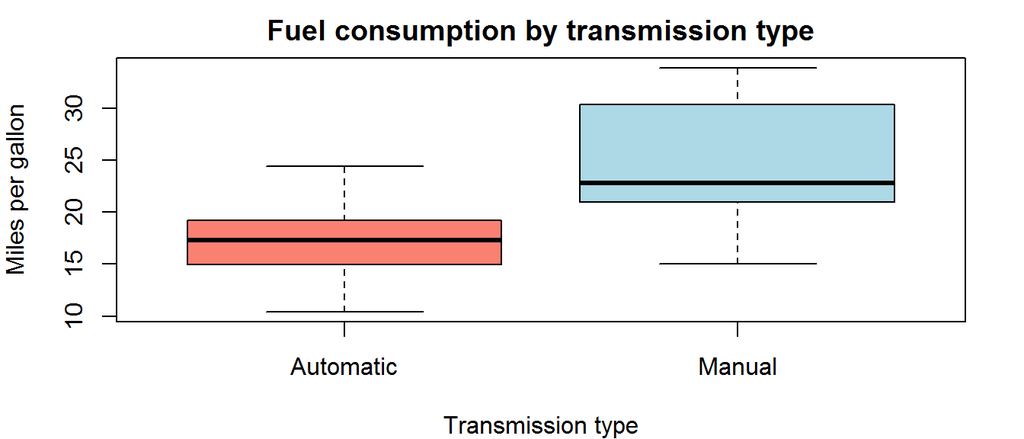

The difference between mpg for automatic/manual transmission is noticalbe even with naked eye. While exploring pairwise `mtcars` plot we can also notice dependencies between mpg and other variables (plot in appendix). So, it’s necessary to build a model.

### Building a model

First of all, assume that our model is $mpg = \beta_{0} + \beta_{1}cyl + \beta_{2}disp + \beta_{3}hp+ \beta_{4}drat + \beta_{5}wt + \beta_{6}qsec + \beta_{7}vs + \beta_{8}am + \beta_{9}gear + \beta_{10}carb + \epsilon$ Now we have to find out significant predictors i.e. throw away that $\beta_{i} \approx 0, i = \overline{1,n}$. For this we can apply model selection algorithm, which compares models generated from base and select the best by Akaike information criterion.

```r
fit <- lm(mpg ~ ., data = mtcars)
fit <- step(fit, trace = FALSE) ## Applying algo
fit
```

```
##
## Call:
## lm(formula = mpg ~ cyl + hp + wt + am, data = mtcars)
##
## Coefficients:
## (Intercept)         cyl6         cyl8           hp           wt
##     33.7083      -3.0313      -2.1637      -0.0321      -2.4968
##    amManual
##      1.8092
```

And appropriate plot

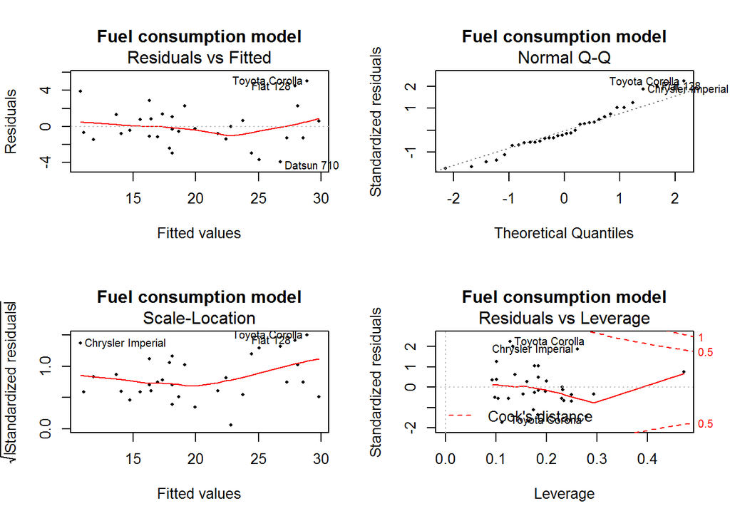

Remarks:

1. Residuals vs. Fitted seems has random pattern.
2. Observations on Q-Q plot are close to line, so residuals are normally distributed.
3. There are few outliers.

### Statistical inference

Assume following hypothesis $H_{0}: MPG_{Auto} = MPG_{Manual}$ and $H_{a}: MPG_{Auto} \neq MPG_{Manual}$. Let’s provide test.

```r
t.test(mpg ~ am, data = mtcars)
```

```
##
##  Welch Two Sample t-test
##
## data:  mpg by am
## t = -3.767, df = 18.33, p-value = 0.001374
## alternative hypothesis: true difference in means is not equal to 0
## 95 percent confidence interval:
##  -11.28  -3.21
## sample estimates:
## mean in group Automatic    mean in group Manual
##                   17.15                   24.39
```

### Appendix

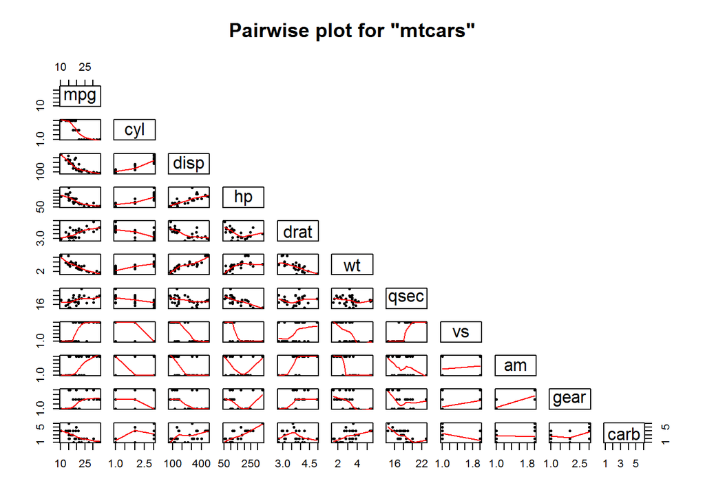